# Рынок заведений общественного питания Москвы

# Содержание

## Описание проекта

В данном проекте проводится исследование рынка общественного питания в Москве. Заказчики исследования - партнёры по открытию бизнеса и инвесторы, которых интересует текущее положение дел на рынке и перспективы развития на будущее. Инвесторов интересует, сможет ли небольшое оригинальное кафе, где гостей будут обслуживать роботы, снискать популярность на долгое время.

**Основные задачи**:

- `исследовать текущее положение дел на рынке обществ.питания`:
  - какие виды объектов есть, каково их соотношение, какие виды наиболее популярны
  - сколько сетевых и несетевых объектов
  - для каких объектов наиболее характерно сетевое распространение
  - что характерно для сетевых объектов (какое количество заведений в сети, какое количество посадочных мест)
  - какое среднее количество посадочных мест у разных видов заведений
  - какие улицы и районы наиболее "успешны" и перспективны в плане количества объектов обществ.питания
  - какие улицы и районы имеют наименьшее количество объектов, какие выводы можно из этого сделать
  - распределение количества посадочных мест на улицах с наибольшим числом объектов и на остальных улицах
- `обдумать перспективы развития на будущее для небольшого кафе`:
  - какой вид заведения предпочтителен
  - какое количество посадочных мест оптимально для заведения выбранного типа
  - на что ориентироваться при выборе места расположения
  - что нужно учитывать для перспективы развития этого проекта из единичного в сетевой
  - что нужно, чтобы обеспечить популярность заведения на долгое время

**План работы**:

- открытие и знакомство с данными
- предобработка данных
- анализ данных, построение графиков
- подключение данных из внешних источников
- продолжение анализа и визуализации данных
- выводы, рекомендации
- презентация

**Описание данных**:

Исследование проходит на открытых данных о заведениях общественного питания в Москве.

## Открытие и изучение данных

```python
import pandas as pd
import os

import numpy as np
from numpy import median

import seaborn as sns
import matplotlib.pyplot as plt

import warnings
warnings.filterwarnings("ignore")
```

```python
if os.path.exists('/datasets/rest_data.csv'):
    df = pd.read_csv('/datasets/rest_data.csv')
else:
    df = pd.read_csv('/C:/datasets/rest_data.csv')
```

```python
def my_check_function (dataset):
    '''Функция для ознакомления и проверки даных'''
    print('Как выглядят случайные 5 строк:')
    display(dataset.sample(5, random_state=42))
    print()
    print('Общая информация о данных, наименования столбцов, типы данных:')
    print(dataset.info())
    print()
    print('Есть ли пропуски, сколько их:')
    print(dataset.isna().sum())
    print('Доля пропущенных значений:')
    print(dataset.isna().mean())
    print()
    print('Есть ли явные дубликаты, сколько их:')
    print(dataset.duplicated().sum())
    print('Доля явных дубликатов:')
    print(dataset.duplicated().mean())
    print()
    print('Подробное описание данных:')
    display(dataset.describe())
```

```python
my_check_function(df)
```

```
Как выглядят случайные 5 строк:
```

|  | id | object_name | chain | object_type | address | number |
| --- | --- | --- | --- | --- | --- | --- |
| 12062 | 182973 | БУРГЕР КИНГ | да | кафе | город Москва, Ярославское шоссе, дом 69 | 60 |
| 8819 | 156321 | Кафе «Тетя Мотя» | нет | кафе | город Москва, проезд Сокольнического Круга, дом 7 | 100 |
| 14197 | 206042 | Чебуречная | нет | магазин (отдел кулинарии) | город Москва, Открытое шоссе, дом 9, строение 9 | 0 |
| 6081 | 156891 | Чудо Пекарня Шаргунь | нет | закусочная | город Москва, Севастопольский проспект, дом 15... | 0 |
| 2478 | 27730 | Столовая «ГАЛА ПИЦЦА» | нет | столовая | город Москва, Варшавское шоссе, дом 116 | 46 |

```
Общая информация о данных, наименования столбцов, типы данных:
<class 'pandas.core.frame.DataFrame'>
RangeIndex: 15366 entries, 0 to 15365
Data columns (total 6 columns):
 #   Column       Non-Null Count  Dtype
---  ------       --------------  -----
 0   id           15366 non-null  int64
 1   object_name  15366 non-null  object
 2   chain        15366 non-null  object
 3   object_type  15366 non-null  object
 4   address      15366 non-null  object
 5   number       15366 non-null  int64
dtypes: int64(2), object(4)
memory usage: 720.4+ KB
None

Есть ли пропуски, сколько их:
id             0
object_name    0
chain          0
object_type    0
address        0
number         0
dtype: int64
Доля пропущенных значений:
id             0.0
object_name    0.0
chain          0.0
object_type    0.0
address        0.0
number         0.0
dtype: float64

Есть ли явные дубликаты, сколько их:
0
Доля явных дубликатов:
0.0

Подробное описание данных:
```

|  | id | number |
| --- | --- | --- |
| count | 15366.000000 | 15366.000000 |
| mean | 119720.066901 | 59.547182 |
| std | 73036.130732 | 74.736833 |
| min | 838.000000 | 0.000000 |
| 25% | 28524.000000 | 12.000000 |
| 50% | 144974.500000 | 40.000000 |
| 75% | 184262.250000 | 80.000000 |
| max | 223439.000000 | 1700.000000 |

### Вывод

- в данных 15366 строк
- тип данных в колонках нареканий не вызывает
- пропусков нет
- явных дубликатов нет

На первый взгляд с данными всё в порядке, но в следующем шаге на всякий случай перепроверим данные в каждом столбце на наличие артефактов/некорректных записей/скрытых дубликатов, затем при необходимости обработаем их.

## Предобработка данных

В данных 6 столбцов, пройдёмся по каждому из них по очереди:

1. id — идентификатор объекта;
2. object_name — название объекта общественного питания;
3. chain — сетевой ресторан;
4. object_type — тип объекта общественного питания;
5. address — адрес;
6. number — количество посадочных мест.

### id — идентификатор объекта

```python
df['id'].duplicated().sum()
```

```
0
```

```python
df['id'].sort_values().unique()
```

```
array([   838,   5882,  19613, ..., 223437, 223438, 223439], dtype=int64)
```

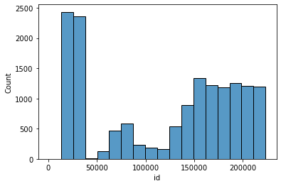

```python
sns.histplot(df['id']);
```

**Вывод**: в столбце с идентификаторами объектов дубликатов не обнаружено. Есть необычное (неравномерное) распределение номеров идентификаторов (на графике выше), но для текущего исследования это принципиального значения не имеет. Нет необходимости углубляться в этот вопрос и вносить изменения в данные.

### object_name — название объекта общественного питания

```python
df['object_name'].duplicated().sum()
```

```
4973
```

```python
df['object_name'].value_counts().head(10)
```

```
Столовая           267
Кафе               236
Шаурма             234
KFC                155
Шоколадница        142
Макдоналдс         122
Бургер Кинг        122
Домино'с Пицца      86
Теремок             84
Крошка Картошка     82
Name: object_name, dtype: int64
```

- в столбце с названиями объектов общественного питания много дубликатов (4973)
- большая часть из них это либо:
  - совпадение названия и типа объекта (столовая, кафе, шаурма), либо
  - название сети (KFC, Шоколадница и т.д.)

```python
dupl_name = df.loc[df['object_name'].duplicated()==True]
len(dupl_name)
```

```
4973
```

```python
dupl_name_add = dupl_name.loc[dupl_name['address'].duplicated()==True]
len(dupl_name_add)
```

```
1634
```

```python
dupl_name_add.duplicated(subset=['object_name', 'address', 'number']).sum()
```

```
47
```

- среди 4973 строк с дубликатами названий объектов оказалось:
  - 1634 дубликатов адресов
  - 47 дубликатов названий + адресов + количества посадочных мест

Такое дублирование привело к мысли о проверке всех данных на скрытые дубликаты. И действительно, оказывается, если проверить все столбцы таблицы кроме id (где, как мы ранее выяснили, нет дубликатов), то мы увидим достаточно много строк-дубликатов, где повторяется вся информация, кроме id. Наиболее вероятно, что это не случайные совпадения, а действительно дубликаты, от которых лучше избавиться для точности дальнейшего анализа.

```python
(df
  .loc[df.duplicated(keep=False, subset=['object_name', 'chain', 'object_type','address', 'number']) == True]
  .sort_values(by=['address', 'number'])
)
```

|  | id | object_name | chain | object_type | address | number |
| --- | --- | --- | --- | --- | --- | --- |
| 5187 | 107462 | Кафе | нет | кафе | город Москва, 1-я Останкинская улица, дом 55 | 5 |
| 5188 | 107466 | Кафе | нет | кафе | город Москва, 1-я Останкинская улица, дом 55 | 5 |
| 5190 | 107480 | Кафе | нет | кафе | город Москва, 1-я Останкинская улица, дом 55 | 5 |
| 5184 | 107456 | Кафе | нет | кафе | город Москва, 1-я Останкинская улица, дом 55 | 10 |
| 5186 | 107574 | Кафе | нет | кафе | город Москва, 1-я Останкинская улица, дом 55 | 10 |
| ... | ... | ... | ... | ... | ... | ... |
| 14223 | 205506 | Кафе | нет | кафе | город Москва, улица Трофимова, владение 36 | 40 |
| 6420 | 19756 | БАР | нет | бар | город Москва, улица Улофа Пальме, дом 5, строе... | 10 |
| 6423 | 19759 | БАР | нет | бар | город Москва, улица Улофа Пальме, дом 5, строе... | 10 |
| 10137 | 172648 | Шаурма | нет | предприятие быстрого обслуживания | город Москва, улица Черняховского, дом 4А | 0 |
| 10510 | 173865 | Шаурма | нет | предприятие быстрого обслуживания | город Москва, улица Черняховского, дом 4А | 0 |

144 rows × 6 columns

```python
df_raw = df
df = df.drop_duplicates(subset=['object_name', 'chain', 'object_type','address', 'number'])
len(df)
```

```
15284
```

```python
len(df_raw) - len(df)
```

```
82
```

```python
((len(df_raw) - len(df)) / 15366) * 100
```

```
0.5336457113106859
```

Было удалено 82 строки. Это составляет 0.5% от первоначального объёма данных.

```python
df['object_name'].sort_values().head(20).unique()
```

```
array(['1-ЫЙ МОСКОВСКИЙ КАДЕТСКИЙ КОРПУС', '1-й МОК',
       '100 личная столовая', '100 личное кафе', '1001 ночь', '100лоФФка',
       '101 вкус', '13 RULES', '13 RULES KRAFT BEER', '13 Rules',
       '15 Kitchen+bar', '18 АВТОБУСНЫЙ ПАРК', '19bar Atmosphere',
       '1x bet', '2-Й АВТОБУСНЫЙ ПАРК', "23'00", '24 Градуса', '259'],
      dtype=object)
```

```python
df.query('object_name == "13 RULES" | object_name == "13 Rules"')
```

|  | id | object_name | chain | object_type | address | number |
| --- | --- | --- | --- | --- | --- | --- |
| 12294 | 199956 | 13 Rules | нет | бар | город Москва, Волховский переулок, дом 2 | 24 |
| 14239 | 211469 | 13 RULES | нет | бар | город Москва, Люблинская улица, дом 165, корпус 1 | 15 |

```python
df['object_name'].sort_values().tail(20).unique()
```

```
array(['столовая при школе № 788', 'столовая при школе № 920',
       'столовая при школе №450', 'школа 1039', 'школа 1143',
       'школа 1186', 'школа 1877', 'школа 1986', 'школа 2010',
       'школа 2011', 'школа 2012', 'школа 335', 'школа 338', 'школа 393',
       'школа 460', 'школа 476', 'школа 772', 'школа 775', 'школа 913',
       'школа 919'], dtype=object)
```

Если присмотреться к названиям объектов ещё, то мы увидим некоторых претендентов на звание "скрытый дубликат", как например, названия "13 Rules" и "13 RULES", но если взглянуть на их адреса, оказывается, что это действительно разные объекты, ещё и не являющиеся сетевыми заведениями. Получается, что приведение к одному шрифту (например, сделать все записи строчными буквами) исказит часть данных, которые могли специально писаться по-разному. Если бы целью исследования было выявление лидирующей сети, то смысл в таком изменении был бы, но в нашем исследовании другие цели, так что изменений производить пока не будем.

Также есть разночтения в оформлении названий объектов обществ.питания в школах: часть названа "столовая при школе №...", часть названа просто "школа №...", вероятно, отсюда и большое количество дубликатов "столовая" (возможно, они находятся в различных госуд.учреждениях и у них нет отдельных названий).

**Вывод**:

В столбце есть дубликаты, они обусловлены двумя причинами:

- совпадение названия и типа объекта (столовая, кафе, шаурма)
- название сети (KFC, Шоколадница и т.д.)

При исследовании этого столбца были найдены скрытые дубликаты, было удалено 82 строки (0.5% от начального объёма данных).

### chain — сетевой ресторан

```python
df['chain'].value_counts()
```

```
нет    12320
да      2964
Name: chain, dtype: int64
```

```python
dupl_name['chain'].value_counts()
```

```
нет    2714
да     2259
Name: chain, dtype: int64
```

В столбце chain есть однозначный ответ ("да" или "нет") на вопрос, является ли объект частью сети ресторанов или нет.

Но вот что интересно:

- данные говорят, что сетевыми ресторанами являются 2964 объекта
- но среди объектов с дубликатами названий сетевыми ресторанами являются только 2259 объектов

То есть у части сетевых ресторанов не дублируются названия (как например, KFC, Шоколадница). Возможно, это специально так задумано, а, возможно, в данных всё-таки есть опечатки/нестандартные записи, которые смогут немного исказить дальнейшее исследование.

Если, например, объекты называются "Шоколадница", и при этом появляется запись "кафе "Шоколадница"", и количество посадочных мест и тип объектов у них одинаковые, то это вызывает вопросы (возможно, это нестандартный вариант записи заведения и это помешает объективному анализу данных). Если же, например, объекты называются "Шоколадница" и "кафе "Шоколадница"" и у них есть различия в столбцах object type и number, тогда будем предполагать, что это сознательное различие в названиях заведений одной сети.

```python
chain_yes = df.loc[df['chain'] == 'да'] #все строки с сетевыми заведениями
len(chain_yes)
```

```
2964
```

```python
chain_dif_names = chain_yes.loc[chain_yes['object_name'].duplicated() == False] #сетевые заведения без дубликатов в названиях
len(chain_dif_names)
```

```
724
```

```python
chain_dif_names
```

|  | id | object_name | chain | object_type | address | number |
| --- | --- | --- | --- | --- | --- | --- |
| 3 | 21894 | ПИЦЦЕТОРИЯ | да | кафе | город Москва, Абрамцевская улица, дом 1 | 40 |
| 6 | 148815 | Брусника | да | кафе | город Москва, переулок Сивцев Вражек, дом 6/2 | 10 |
| 13 | 22579 | Алло Пицца | да | кафе | город Москва, улица Авиаторов, дом 14 | 32 |
| 16 | 144107 | Суши Wok | да | предприятие быстрого обслуживания | город Москва, Азовская улица, дом 3 | 7 |
| 18 | 58565 | Тануки | да | ресторан | город Москва, Большая Академическая улица, дом 65 | 160 |
| ... | ... | ... | ... | ... | ... | ... |
| 15341 | 211269 | Лаундж-бар «Мята Lounge» | да | бар | город Москва, Днепропетровская улица, дом 2Б | 45 |
| 15343 | 211767 | Бар Мята Lounge | да | бар | город Москва, Митинская улица, дом 16 | 5 |
| 15344 | 206756 | Мята Lounge Октябрьская | да | кафе | город Москва, Донская улица, дом 11, строение 2 | 48 |
| 15347 | 222491 | Кальянная «Мята Lounge» | да | кафе | город Москва, Профсоюзная улица, дом 142, корп... | 40 |
| 15350 | 213061 | Мята | да | кафетерий | город Москва, Каширское шоссе, дом 96, корпус 1 | 35 |

724 rows × 6 columns

```python
chain_dif_names.sort_values(by='object_name').head(15)
```

|  | id | object_name | chain | object_type | address | number |
| --- | --- | --- | --- | --- | --- | --- |
| 13384 | 193929 | Beverly Hills Diner | да | ресторан | город Москва, Никольская улица, дом 10 | 88 |
| 1187 | 22245 | Bierloga | да | кафе | город Москва, Туристская улица, дом 13, корпус 2 | 75 |
| 8524 | 80065 | Black & White | да | кафе | город Москва, поселение Рязановское, посёлок З... | 40 |
| 6186 | 125150 | Bocconcino | да | ресторан | город Москва, Ленинский проспект, дом 109 | 68 |
| 12111 | 185023 | BooBo | да | ресторан | город Москва, Дмитровское шоссе, дом 73, строе... | 46 |
| 12087 | 94206 | Bubbleology | да | кафе | город Москва, Ходынский бульвар, дом 4 | 6 |
| 5599 | 97093 | Burger Club | да | предприятие быстрого обслуживания | город Москва, шоссе Энтузиастов, дом 31 | 35 |
| 8978 | 159536 | COFIX | да | кафе | город Москва, площадь Киевского Вокзала, дом 1 | 10 |
| 8448 | 58629 | CORREAS | да | ресторан | город Москва, улица Льва Толстого, дом 16 | 32 |
| 15084 | 214843 | CoffeeShop | да | ресторан | город Москва, Кутузовский проспект, дом 57 | 0 |
| 6676 | 139512 | Coffeeshop Company | да | ресторан | город Москва, площадь Киевского Вокзала, дом 2 | 85 |
| 9096 | 163088 | Cofix | да | кафе | город Москва, улица Солянка, дом 2/6, строение 1 | 3 |
| 8740 | 154505 | Cookhouse | да | предприятие быстрого обслуживания | город Москва, Хорошёвское шоссе, дом 27 | 4 |
| 7910 | 24337 | Correas | да | кафе | город Москва, улица Большая Ордынка, дом 40, с... | 30 |
| 919 | 78111 | Costa Coffee | да | кафе | город Москва, улица Большая Полянка, дом 30 | 50 |

```python
chain_dif_names.sort_values(by='object_name').tail(20)
```

|  | id | object_name | chain | object_type | address | number |
| --- | --- | --- | --- | --- | --- | --- |
| 8086 | 25599 | Шоколадница Кофемания | да | кафе | город Москва, улица Арбат, дом 1 | 25 |
| 1193 | 24737 | Штирбирлиц | да | ресторан | город Москва, улица 1905 Года, дом 4 | 48 |
| 497 | 84317 | Штолле | да | кафе | город Москва, Краснопрудная улица, дом 22-24 | 35 |
| 8006 | 69398 | Югос | да | ресторан | город Москва, Донская улица, дом 15 | 48 |
| 601 | 24856 | ЯКИТОРИЯ | да | ресторан | город Москва, Ленинский проспект, дом 68/10 | 96 |
| 15053 | 24965 | ЯКИТОРИЯ И СПОРТ БАР | да | ресторан | город Москва, улица Новый Арбат, дом 10 | 99 |
| 5984 | 92405 | ЯММИ МИКС | да | кафетерий | город Москва, шоссе Энтузиастов, дом 12, корпус 2 | 2 |
| 6161 | 91152 | ЯПОША | да | ресторан | город Москва, Профсоюзная улица, дом 129А | 150 |
| 284 | 58463 | Якитория | да | ресторан | город Москва, 1-я Тверская-Ямская улица, дом 7 | 80 |
| 2328 | 24716 | Якитория и Ян Примус | да | ресторан | город Москва, Спартаковская улица, дом 25/28, ... | 282 |
| 6601 | 69821 | Ян Примус | да | ресторан | город Москва, Осенний бульвар, дом 7, корпус 1 | 300 |
| 15055 | 222090 | Японский ресторан «Ваби-Саби» | да | ресторан | город Москва, Кантемировская улица, дом 47 | 155 |
| 11891 | 94971 | Япоша | да | кафе | город Москва, Ходынский бульвар, дом 4 | 60 |
| 6509 | 19973 | кафе «Му-Му» | да | кафе | город Москва, улица Покрышкина, дом 4 | 100 |
| 7821 | 24047 | кафе «Нияма» | да | кафе | город Москва, Пятницкая улица, дом 3/4, строен... | 80 |
| 629 | 25523 | кафе «Папа Джонс» | да | кафе | город Москва, Люсиновская улица, дом 41, строе... | 24 |
| 6295 | 21820 | кафе «Старбакс» | да | кафе | город Москва, улица Балчуг, дом 3/2 | 62 |
| 3637 | 21782 | кафе «Шоколадница» | да | кафе | город Москва, Климентовский переулок, дом 10, ... | 50 |
| 5048 | 26158 | ресторан «Брудер» | да | ресторан | город Москва, Бутырская улица, дом 46, строение 1 | 86 |
| 148 | 27207 | ресторан «Якитория» | да | кафе | город Москва, Валовая улица, дом 8/18 | 124 |

Возможные причины появления сетевых заведений без одинаковых названий:

1. Так задумано. Разные названия заведений одной сети помогают быстрее сориентироваться, например:
- Лаундж-бар «Мята Lounge»
- Бар Мята Lounge
- Мята Lounge Октябрьская
- Кальянная «Мята Lounge»
- Мята

  У этих заведений разные типы объектов (бар, кафе, кафетерий) и разное количество посадочных мест (от 5 до 48).
1. Название объекта не повторяется, но он является частью сети, которая больше не имеет объектов в Москве, но имеет их других городах и странах (то есть это никакая не ошибка). Возможно, сюда входят такие рестораны, как например, "Beverly Hills Diner".
1. Возможно объект был частью небольшой сети буквально из нескольких заведений (3-4), но остальные объекты закрылись, а объект остался со статусом сетевого; или объект перешёл к другому владельцу и стал частью другой сети заведений нового владельца, но названия объектов между собой никак не взаимосвязаны, и поэтому юридически объекты являются сетью заведений одного владельца/группы компаний, но это не отражается на их названиях.
1. Сомнения вызывают такие строки, как, например,

8978 159536 COFIX да кафе город Москва, площадь Киевского Вокзала, дом 1 10

9096 163088 Cofix да кафе город Москва, улица Солянка, дом 2/6, строение 1 3

То есть одно и то же название записано разным шрифтом, тип заведения один и тот же (кафе), количество посадочных мест сопоставимо (10 и 3). Но вносить изменения без абсолютной уверенности может быть неверно (например, нам уже встречались "13 RULES" и "13 Rules", которые оказались действительно разными заведениями).

1. Больше всего вопросов вызывает отсортированный конец списка, ведь здесь, например, встречаются такие названия:
- ЯКИТОРИЯ
- ЯКИТОРИЯ И СПОРТ БАР
- Якитория
- Якитория и Ян Примус
- ресторан «Якитория»

Они кажутся частью одной сети, но имеют разные записи, что ж, возможно это похоже на ситуацию, описанную в пункте 1 ("так задумано"). И изменять эти данные не имеет смысла.

Но есть и такие объекты как

- кафе «Му-Му»
- кафе «Старбакс»
- кафе «Шоколадница», которые явно являются частью большой сети и это единичное название объекта сети, записанное отличным образом от основной части.

```python
df.loc[df['object_name'] == 'кафе «Му-Му»']
```

|  | id | object_name | chain | object_type | address | number |
| --- | --- | --- | --- | --- | --- | --- |
| 6509 | 19973 | кафе «Му-Му» | да | кафе | город Москва, улица Покрышкина, дом 4 | 100 |

```python
df.loc[df['object_name'] == 'Му-Му']
```

|  | id | object_name | chain | object_type | address | number |
| --- | --- | --- | --- | --- | --- | --- |
| 37 | 24968 | Му-Му | да | кафе | город Москва, улица Арбат, дом 4, строение 1 | 125 |
| 53 | 21998 | Му-Му | да | кафе | город Москва, улица Арбат, дом 45/24 | 220 |
| 856 | 25558 | Му-Му | да | кафе | город Москва, 9-я Парковая улица, владение 61А... | 200 |
| 1681 | 24661 | Му-Му | да | кафе | город Москва, Сокольническая площадь, дом 9 | 130 |
| 2429 | 20102 | Му-Му | да | кафе | город Москва, город Зеленоград, корпус 403А | 200 |
| 3564 | 127911 | Му-Му | да | кафе | город Москва, улица Большая Дмитровка, дом 9, ... | 154 |
| 4449 | 124617 | Му-Му | да | кафе | город Москва, Карманицкий переулок, дом 9 | 150 |
| 5295 | 26929 | Му-Му | да | кафе | город Москва, улица Пришвина, дом 22 | 90 |
| 5676 | 26200 | Му-Му | да | кафе | город Москва, Зелёный проспект, дом 54А | 195 |
| 5967 | 104941 | Му-Му | да | столовая | город Москва, Люблинская улица, дом 169, корпус 2 | 55 |
| 6158 | 21700 | Му-Му | да | ресторан | город Москва, Профсоюзная улица, дом 129А | 180 |
| 6603 | 70505 | Му-Му | да | кафе | город Москва, Осенний бульвар, дом 7, корпус 1 | 150 |
| 7120 | 84922 | Му-Му | да | кафе | город Москва, Фестивальная улица, дом 2Б | 53 |
| 8097 | 144280 | Му-Му | да | кафе | город Москва, Нижний Сусальный переулок, дом 5... | 95 |
| 15250 | 207422 | Му-Му | да | кафе | город Москва, Ленинградский проспект, дом 62А | 65 |

```python
df.loc[df['object_name'] == 'Му-му']
```

|  | id | object_name | chain | object_type | address | number |
| --- | --- | --- | --- | --- | --- | --- |
| 1931 | 22513 | Му-му | да | кафе | город Москва, улица Рождественка, дом 5/7, стр... | 60 |

```python
df.loc[df['object_name'] == 'МУ-МУ']
```

|  | id | object_name | chain | object_type | address | number |
| --- | --- | --- | --- | --- | --- | --- |
| 73 | 22366 | МУ-МУ | да | кафе | город Москва, Бауманская улица, дом 35/1 | 160 |
| 255 | 25111 | МУ-МУ | да | кафе | город Москва, Малый Гнездниковский переулок, д... | 120 |
| 2345 | 24921 | МУ-МУ | да | кафе | город Москва, Мясницкая улица, дом 14/2, строе... | 150 |
| 5166 | 25237 | МУ-МУ | да | кафе | город Москва, проспект Мира, дом 114Б, строение 2 | 273 |
| 5605 | 25551 | МУ-МУ | да | предприятие быстрого обслуживания | город Москва, Семёновская площадь, дом 1 | 100 |
| 6368 | 135698 | МУ-МУ | да | кафе | город Москва, Манежная площадь, дом 1, строение 2 | 90 |
| 8049 | 25167 | МУ-МУ | да | кафе | город Москва, Комсомольский проспект, дом 26 | 300 |
| 15251 | 210046 | МУ-МУ | да | кафе | город Москва, Новослободская улица, дом 4 | 120 |

Получается, что заведения одной сети записаны в имеющихся данных несколькими способами:

- МУ-МУ
- Му-Му
- Му-му
- кафе «Му-Му»

Если бы целью исследования было определение лидеров рейтинга сетевых заведений, такие записи были бы препятствием на пути объективного анализа.

Для нашего исследования это не является целью, так что данные оставляем без изменений.

**Вывод**: при анализе этого столбца были выявлены некоторые нюансы в данных, но никаких изменений производить не требуется. Данные пригодны для дальнейшей работы.

### object_type — тип объекта общественного питания

```python
df['object_type'].value_counts()
```

```
кафе                                 6071
столовая                             2584
ресторан                             2282
предприятие быстрого обслуживания    1898
бар                                   855
буфет                                 577
кафетерий                             395
закусочная                            349
магазин (отдел кулинарии)             273
Name: object_type, dtype: int64
```

**Вывод**: ничего подозрительного или необычного не замечено, данные пригодны для анализа.

### address — адрес

```python
df['address'].duplicated().sum()
```

```
6176
```

```python
df['address'].value_counts()
```

```
город Москва, Ходынский бульвар, дом 4                          95
город Москва, Пресненская набережная, дом 2                     63
город Москва, проспект Мира, дом 211, корпус 2                  60
город Москва, Кировоградская улица, дом 13А                     52
город Москва, площадь Киевского Вокзала, дом 2                  47
                                                                ..
город Москва, Шереметьевская улица, дом 28                       1
город Москва, Большая Переяславская улица, дом 1, строение 1     1
город Москва, проспект Мира, дом 87                              1
город Москва, Новомосковская улица, дом 15А, строение 1          1
город Москва, улица Новый Арбат, дом 13                          1
Name: address, Length: 9108, dtype: int64
```

```python
df['address'].sort_values()
```

```
7691                     1-й Нагатинский проезд, дом 10
8903     1-я Тверская-Ямская улица, дом 29/66, корпус 1
8776             2-я Брестская улица, дом 1, строение 1
10715            2-я Брестская улица, дом 5, строение 1
8860                5-й Котельнический переулок, дом 11
                              ...
12403                       улица Льва Толстого, дом 18
12401                       улица Льва Толстого, дом 18
8899                       улица Миклухо-Маклая, дом 18
8826                 улица Обручева, дом 23, строение 1
11615           улица Сергея Макеева, дом 9, строение 2
Name: address, Length: 15284, dtype: object
```

**Вывод**:

В этом столбце достаточно много дубликатов (6176), что естественно, если взглянуть на то, какие адреса чаще всего повторяются:

- город Москва, Ходынский бульвар, дом 4 - ТЦ Авиапарк
- город Москва, Пресненская набережная, дом 2 - Москва-Сити
- город Москва, проспект Мира, дом 211, корпус 2 - ТРК Европолис

Но что важно отметить, формат записи адресов отличается: где-то запись начинается со слов "город Москва", а где-то сразу с названия улиц. Это надо будет учитывать при выделении в отдельный столбец информации об улице из этого столбца.

### number — количество посадочных мест

```python
df['number'].value_counts()
```

```
0      1589
40      832
20      724
30      681
10      638
       ...
229       1
356       1
481       1
167       1
119       1
Name: number, Length: 315, dtype: int64
```

```python
df['number'].sort_values().tail(10)
```

```
13299     700
5649      760
9955      920
2313     1040
3686     1200
4480     1200
9064     1288
8345     1400
8148     1500
12723    1700
Name: number, dtype: int64
```

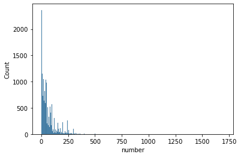

```python
sns.histplot(df['number']);
```

В этом столбце есть неожиданные значения - много заведений с количеством посадочных мест 0 (таких заведений 1589).

С другой стороны, это может быть вполне объяснимым: заведения продают еду на вынос. Если мы взглянем на строки с таким значением, мы увидим, что это действительно такие точки, как "Шаурма, куры-гриль" или "Милти"(готовые блюда).

Также необычно выглядят максимальные значения посадочных мест (1700, 1500 и др.).

График распределения показывает, что основная масса значений приходится на диапазон от 0 до 250 мест.

Попробуем подробнее рассмотреть все моменты, вызывающие сомнения.

```python
df.loc[df['number'] == 0]
```

|  | id | object_name | chain | object_type | address | number |
| --- | --- | --- | --- | --- | --- | --- |
| 137 | 115498 | Пекарня & Донер | нет | закусочная | город Москва, Бутырская улица, дом 9, корпус 2 | 0 |
| 154 | 152556 | Шаурма в пите | нет | предприятие быстрого обслуживания | город Москва, Варшавское шоссе, дом 72, корпус 2 | 0 |
| 157 | 149568 | Суши | нет | предприятие быстрого обслуживания | город Москва, улица Маршала Василевского, дом ... | 0 |
| 190 | 126956 | Шаурма, куры-гриль | нет | предприятие быстрого обслуживания | город Москва, 1-я Владимирская улица, дом 21 | 0 |
| 195 | 149531 | Шаурма, куры-гриль | нет | предприятие быстрого обслуживания | город Москва, 2-я Владимирская улица, дом 44/10 | 0 |
| ... | ... | ... | ... | ... | ... | ... |
| 15334 | 211228 | МИЛТИ | да | магазин (отдел кулинарии) | город Москва, Дубравная улица, дом 34/29 | 0 |
| 15335 | 211221 | МИЛТИ | да | магазин (отдел кулинарии) | город Москва, Пятницкое шоссе, дом 3 | 0 |
| 15336 | 211209 | Готовые блюда Милти | да | предприятие быстрого обслуживания | город Москва, Ореховый бульвар, дом 22А | 0 |
| 15337 | 208477 | Милти | да | предприятие быстрого обслуживания | город Москва, 3-й Крутицкий переулок, дом 18 | 0 |
| 15338 | 211201 | Милти | да | магазин (отдел кулинарии) | город Москва, Новослободская улица, дом 4 | 0 |

1589 rows × 6 columns

Выделяем отдельно все объекты с нулевым количеством посадочных мест:

```python
number_0 = df.loc[df['number'] == 0]
number_0['object_type'].value_counts()
```

```
предприятие быстрого обслуживания    690
кафе                                 306
закусочная                           182
магазин (отдел кулинарии)            145
кафетерий                            111
буфет                                 64
ресторан                              44
бар                                   28
столовая                              19
Name: object_type, dtype: int64
```

Возможные причины нулевого количества посадочных мест:

- это специфика типа объекта: например, предприятие быстрого обслуживания, магазин(отдел кулинарии), где и не предусматривается никаких посадочных мест (никто ведь не станет есть блюдо прямо в магазине)
- тип объекта может предусматривать посадочные места, а может - и нет, например, закусочная или буфет
- тип объекта базово предполагает наличие посетителей (например, ресторан), но некоторые заведения такого типа, возможно, настроены именно на доставку. В любом случае заменить 0, не погрешив против истины, будет сложно (отличить ресторан с пропуском количества мест от ресторана, задуманного на работу именно по доставке, на данный момент представляется невозможным).
- тип объекта (например, столовая) расположен в госуд.учреждении (например, в школе), и помещение и посадочные места принадлежат именно этому госуд.заведению, и поэтому к самому объекту отношения юридически не имеют, отсюда мы видим 0.

Вывод: в любом случае заменять 0 не имеет смысла.

```python
len(df.loc[df['number'] > 250])
```

```
286
```

```python
(len(df.loc[df['number'] > 250]) / len(df)) *100
```

```
1.8712378958387856
```

```python
df.loc[df['number'] > 250].sort_values(by='number').tail(10)
```

|  | id | object_name | chain | object_type | address | number |
| --- | --- | --- | --- | --- | --- | --- |
| 13299 | 200905 | White Hall | нет | ресторан | город Москва, Ферганская улица, дом 8 | 700 |
| 5649 | 29232 | СТОЛОВАЯ МОСКОВСКИЙ ГУМАНИТАРНЫЙ УНИВЕРСИТЕТ | нет | столовая | город Москва, улица Юности, дом 5, строение 1 | 760 |
| 9955 | 171116 | EATALY | нет | ресторан | город Москва, Киевская улица, дом 2 | 920 |
| 2313 | 26560 | Ресторан «АЛЬФА» | нет | ресторан | город Москва, Измайловское шоссе, дом 71, корп... | 1040 |
| 4480 | 27024 | РУМ СЕРВИС | нет | ресторан | город Москва, Кутузовский проспект, дом 2/1, с... | 1200 |
| 3686 | 27026 | РУМ СЕРВИС | нет | ресторан | город Москва, площадь Европы, дом 2 | 1200 |
| 9064 | 19719 | КОМБИНАТ ПИТАНИЯ «УПРАВЛЕНИЕ АКАДЕМСЕРВИС» | нет | столовая | город Москва, проспект Вернадского, дом 84, ст... | 1288 |
| 8345 | 27750 | СТОЛОВАЯ-БУФЕТ | нет | столовая | город Москва, улица Волхонка, дом 15 | 1400 |
| 8148 | 80291 | Банкетный зал Шелк | нет | ресторан | город Москва, Большой Саввинский переулок, дом... | 1500 |
| 12723 | 199696 | Arena by Soho Family | нет | бар | город Москва, Кутузовский проспект, дом 36, ст... | 1700 |

Что касается объектов с большим количеством посадочных мест (более 250), то их 286, это менее 2% от общего числа объектов (1.87%). При дальнейшем анализе при необходимости можно будет их не включать в расчёт, но удалять/изменять эти данные тоже смысла не вижу.

**Вывод**: в данных есть много объектов с 0 количеством посадочных мест и есть некоторое количество объектов с необычно большими значениями в этом столбце, но никаких изменений в данные вносить не требуется, данные пригодны для дальнейшего анализа.

### Вывод

В процессе предобработки данных были поочерёдно проверены все столбцы. Были выявлены скрытые дубликаты: удалено 82 строки (0.5% от первоначального объёма данных).

Допольнительно были обнаружены некоторые потенциально проблемные места:

- написание названий объектов одной сети разным шрифтом (МУ-МУ, му-му, и т.д.)
- написание объектов, которые явно принадлежат одной сети, разным способом (Якитория, ресторан "Якитория" и т.д.)
- формат записи адресов отличается: где-то запись начинается со слов "город Москва", а где-то сразу с названия улиц

## Анализ данных

### Исследование соотношения видов объектов общественного питания по количеству

```python
df_type_rating = df.groupby('object_type', as_index=False).agg({'id':'count'}).sort_values(by='id', ascending=False)
df_type_rating.columns = ['object_type', 'object_count']
df_type_rating
```

|  | object_type | object_count |
| --- | --- | --- |
| 3 | кафе | 6071 |
| 8 | столовая | 2584 |
| 7 | ресторан | 2282 |
| 6 | предприятие быстрого обслуживания | 1898 |
| 0 | бар | 855 |
| 1 | буфет | 577 |
| 4 | кафетерий | 395 |
| 2 | закусочная | 349 |
| 5 | магазин (отдел кулинарии) | 273 |

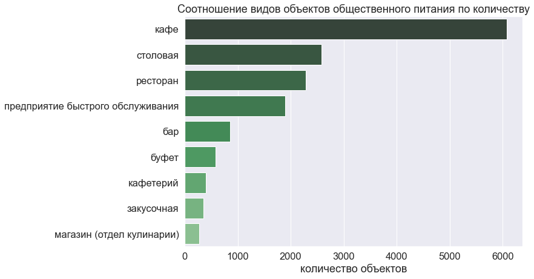

```python
plt.figure(figsize= (10, 7))
plt.style.use('seaborn-whitegrid')
sns.set(font_scale=1.5)
sns.set_palette('Greens_r_d', 10)

ax = sns.barplot(x='object_count', y='object_type', data=df_type_rating)
ax.set_title('Соотношение видов объектов общественного питания по количеству')
ax.set_xlabel('количество объектов')
ax.set_ylabel('')
plt.show();
```

**Вывод**: соотношение видов объектов общественного питания по количеству показывает:

- кафе - самый распространённый вид объектов (более 6 тысяч таких заведений)
- количество заведений таких типов как: столовая, ресторан, предприятие быстрого обслуживания - находится примерно в диапазоне от 2500 до 1900
- остальные виды заведений менее распространены (менее тысячи объектов на каждый вид)

### Исследование соотношения сетевых и несетевых заведений по количеству

```python
df['chain'].value_counts()
```

```
нет    12320
да      2964
Name: chain, dtype: int64
```

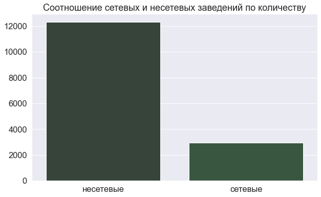

```python
x=['несетевые', 'сетевые']
y=df['chain'].value_counts()

plt.figure(figsize= (10, 6))
ax=sns.barplot(x=x, y=y)
ax.set_title('Соотношение сетевых и несетевых заведений по количеству')
ax.set_ylabel('');
```

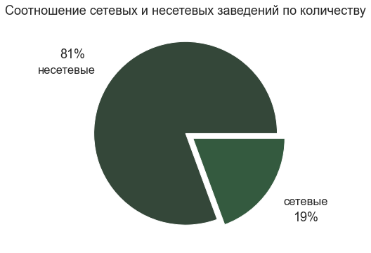

```python
keys=['несетевые', 'сетевые']
y=df['chain'].value_counts()
explode = [0, 0.1]

plt.figure(figsize= (10,6))
plt.pie(y, labels=keys,
        explode=explode, autopct='%.0f%%', pctdistance=1.5, labeldistance=1.2)

plt.title('Соотношение сетевых и несетевых заведений по количеству')
plt.show();
```

**Вывод**: график соотношения сетевых и несетевых заведений по количеству показывает:

- несетевых заведений примерно в 4 раза больше, чем сетевых

### Для какого вида объекта общественного питания характерно сетевое распространение?

```python
chain_yes['object_type'].value_counts()
```

```
кафе                                 1396
предприятие быстрого обслуживания     788
ресторан                              543
магазин (отдел кулинарии)              78
закусочная                             56
кафетерий                              52
бар                                    37
буфет                                  11
столовая                                3
Name: object_type, dtype: int64
```

```python
chain_type_rating = (chain_yes.groupby('object_type', as_index=False).agg({'id': 'count'})
 .sort_values(by='id', ascending=False))
chain_type_rating.columns = ['object_type', 'object_count']
chain_type_rating
```

|  | object_type | object_count |
| --- | --- | --- |
| 3 | кафе | 1396 |
| 6 | предприятие быстрого обслуживания | 788 |
| 7 | ресторан | 543 |
| 5 | магазин (отдел кулинарии) | 78 |
| 2 | закусочная | 56 |
| 4 | кафетерий | 52 |
| 0 | бар | 37 |
| 1 | буфет | 11 |
| 8 | столовая | 3 |

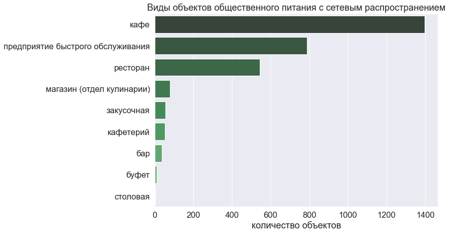

```python
plt.figure(figsize= (10, 7))
ax = sns.barplot(x='object_count', y='object_type', data=chain_type_rating)
ax.set_title('Виды объектов общественного питания с сетевым распространением')
ax.set_xlabel('количество объектов')
ax.set_ylabel('')
plt.show();
```

График видов объектов общественного питания с сетевым распространением показывает:

- кафе - наиболее многочисленная категория объектов с сетевым распространением (1396 объектов такого вида)
- предприятия быстрого обслуживания на втором месте по количеству сетевых заведений (788 сетевых объектов)
- рестораны на третьем месте по количеству сетевых заведений (543 объекта)
- другие виды объектов достаточно малочисленны (у каждого менее 100 сетевых объектов)

Но это всё касается количественного сравнения.

Можно ещё сравнить по другому показателю - по долям, то есть для каждого вида объектов посчитать процент сетевых заведений внутри него. Это и даст ответ на вопрос, для какого вида объекта наиболее характерно сетевое распространение.

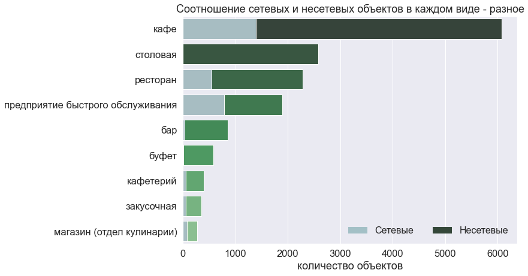

```python
x = df_type_rating['object_count']
y = df_type_rating['object_type']
x_2 = chain_type_rating['object_count']

plt.figure(figsize= (10, 7))
ax = sns.barplot(x=x, y=y)
bottom_plot = sns.barplot(x=x_2, y=y, color='#a3c0c6')

topbar = plt.Rectangle((0,0),1,1, edgecolor = 'none')
bottombar = plt.Rectangle((0,0),1,1,fc='#a3c0c6',  edgecolor = 'none')
l = plt.legend([bottombar, topbar], ['Сетевые', 'Несетевые'], loc=4, ncol = 2, prop={'size':16})
l.draw_frame(False)

ax.set_title('Соотношение сетевых и несетевых объектов в каждом виде - разное')
ax.set_xlabel('количество объектов')
ax.set_ylabel('')
plt.show();
```

```python
table_type_rating = df_type_rating.merge(chain_type_rating, on='object_type')
table_type_rating.columns = ['object_type', 'total_count', 'chain_count']
table_type_rating['percentage_of_chain'] = table_type_rating['chain_count'] / table_type_rating['total_count'] * 100
table_type_rating
```

|  | object_type | total_count | chain_count | percentage_of_chain |
| --- | --- | --- | --- | --- |
| 0 | кафе | 6071 | 1396 | 22.994564 |
| 1 | столовая | 2584 | 3 | 0.116099 |
| 2 | ресторан | 2282 | 543 | 23.794917 |
| 3 | предприятие быстрого обслуживания | 1898 | 788 | 41.517387 |
| 4 | бар | 855 | 37 | 4.327485 |
| 5 | буфет | 577 | 11 | 1.906412 |
| 6 | кафетерий | 395 | 52 | 13.164557 |
| 7 | закусочная | 349 | 56 | 16.045845 |
| 8 | магазин (отдел кулинарии) | 273 | 78 | 28.571429 |

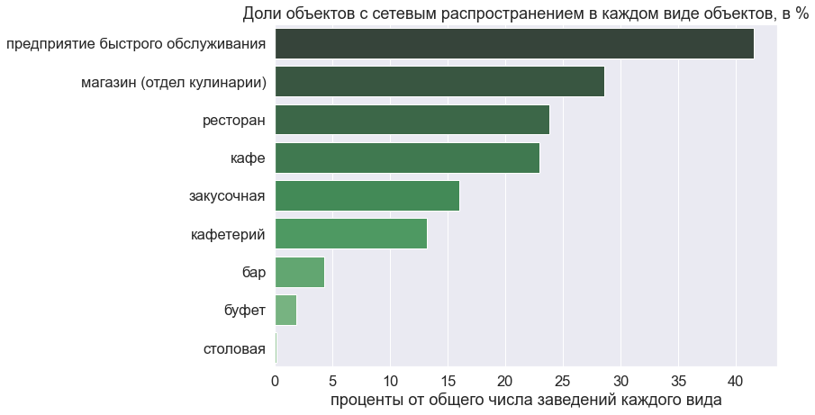

```python
x = table_type_rating.sort_values(by='percentage_of_chain', ascending=False)['percentage_of_chain']
y = table_type_rating.sort_values(by='percentage_of_chain', ascending=False)['object_type']

plt.figure(figsize= (10, 7))
ax = sns.barplot(x=x, y=y)
ax.set_title('Доли объектов с сетевым распространением в каждом виде объектов, в %')
ax.set_xlabel('проценты от общего числа заведений каждого вида')
ax.set_ylabel('')
plt.show();
```

```python
(chain_yes.loc[chain_yes['object_type'] == 'предприятие быстрого обслуживания']['object_name'].str.lower()
 .value_counts().head(20))
```

```
макдоналдс                                         102
kfc                                                 99
бургер кинг                                         93
крошка картошка                                     58
теремок                                             55
домино'с пицца                                      28
милти                                               27
суши wok                                            22
subway                                              22
кофе с собой                                        19
папа джонс                                          17
сабвей                                              10
кафе «kfc»                                          10
пицца хат                                            9
додо пицца                                           8
стардогs                                             8
баскин роббинс                                       7
предприятие быстрого обслуживания «макдоналдс»       6
сушишоп                                              5
предприятие быстрого обслуживания «бургер кинг»      5
Name: object_name, dtype: int64
```

```python
chain_yes.loc[chain_yes['object_type'] == 'магазин (отдел кулинарии)']['object_name'].str.lower().value_counts().head(20)
```

```
милти                                                   27
суши wok                                                10
кулинарная лавка братьев караваевых                      7
пицца паоло                                              3
братья караваевы                                         3
суши сет                                                 3
магазин готовой еды «милти»                              3
волконский                                               3
сушишоп                                                  3
кулинарная лавка братьев караваевых братья караваевы     2
штолле                                                   2
точка продажи готовой еды милти                          1
«кафе «кулинарная лавка братьев караваевых»              1
кафе «кулинарная лавка братьев караваевых»               1
«кафе «кулинарная лавка братьев караваевых»»             1
шантимель                                                1
перекресток                                              1
мираторг                                                 1
билла                                                    1
тирольские пироги                                        1
Name: object_name, dtype: int64
```

```python
chain_yes.loc[chain_yes['object_type'] == 'ресторан']['object_name'].str.lower().value_counts().head(20)
```

```
чайхона №1                37
kfc                       30
тануки                    29
макдоналдс                27
якитория                  25
иль патио                 21
бургер кинг               15
ресторан «тануки»         11
домино'с пицца             9
иль патио планета суши     8
грабли                     8
папа джонс                 8
корчма тарас бульба        8
колбасофф                  7
джон джоли                 7
урюк                       6
теремок                    6
гамбринус                  5
шоколадница                5
ресторан «чайхона №1»      5
Name: object_name, dtype: int64
```

```python
chain_yes.loc[chain_yes['object_type'] == 'кафе']['object_name'].str.lower().value_counts().head(20)
```

```
шоколадница           150
домино'с пицца         51
додо пицца             37
суши wok               35
хинкальная             33
кофе хаус              32
хлеб насущный          30
kfc                    26
прайм стар             25
теремок                25
крошка картошка        24
папа джонс             24
бургер кинг            23
starbucks              23
му-му                  21
макдоналдс             21
мята lounge            20
старбакс               19
андерсон               16
кафе «шоколадница»     16
Name: object_name, dtype: int64
```

```python
chain_yes.loc[chain_yes['object_name'].str.lower() == 'макдоналдс']['object_type'].value_counts()
```

```
предприятие быстрого обслуживания    102
ресторан                              27
кафе                                  21
Name: object_type, dtype: int64
```

```python
chain_yes.loc[chain_yes['object_name'].str.lower() == 'kfc']['object_type'].value_counts()
```

```
предприятие быстрого обслуживания    99
ресторан                             30
кафе                                 26
Name: object_type, dtype: int64
```

```python
chain_yes.loc[chain_yes['object_name'].str.lower() == 'теремок']['object_type'].value_counts()
```

```
предприятие быстрого обслуживания    55
кафе                                 25
закусочная                            6
ресторан                              6
буфет                                 2
Name: object_type, dtype: int64
```

```python
chain_yes.loc[chain_yes['object_name'].str.lower() == 'милти']['object_type'].value_counts()
```

```
магазин (отдел кулинарии)            27
предприятие быстрого обслуживания    27
кафе                                  9
закусочная                            5
буфет                                 2
кафетерий                             1
ресторан                              1
Name: object_type, dtype: int64
```

Дополнительно:

В этом вопросе можно выявить самые многочисленные сети разных видов объектов (кафе, ресторанов и т.д.), чтобы знать конкретно, у кого можно перенимать опыт и на кого ориентироваться. Но на пути такого более детального исследования есть препятствия.

Техническое пожелание: для точного выявления рейтингов различных сетей обществ.питания было бы неплохо названия объектов привести к одному виду (например, есть запись "макдоналдс" и запись "предприятие быстрого обслуживания "макдоналдс"", есть запись "kfc" и есть запись "кафе "kfc"", есть "сабвей" и есть "subway" - все подобные случаи делают подсчёт неточным).

И ещё само распределение сетевых заведений по категориям тоже иногда вызывает вопросы. Например, есть Макдональдс с одинаковым меню, и он записан и как предприятие быстрого обслуживания, и как ресторан, и как кафе (то же самое с KFC, и другими заведениями, например, даже с Теремком есть очень разные варианты классификации). Возможно, это связано с количеством посадочных мест, с типом здания и оформления внутри (но всё равно при наличии одинакового меню это вызывает вопросы). И тем более странным выглядят записи Милти и как предприятия быстрого обслуживания, и как магазин(отдел кулинарии), и кафе, и закусочная, буфет, кафетерий, и даже ресторан.

Таким образом, возможно, для классификации объектов в категории object_type нужны более понятные и прозрачные критерии.

### Что характерно для сетевых заведений: много заведений с небольшим числом посадочных мест в каждом или мало заведений с большим количеством посадочных мест?

```python
chain_yes['object_name'] = chain_yes['object_name'].str.lower()
```

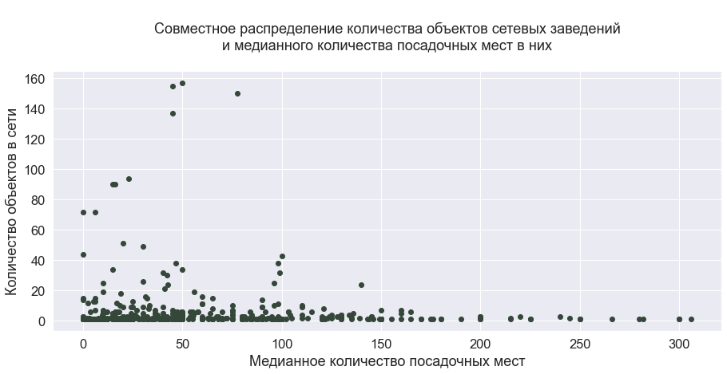

```python
chain_table = chain_yes.groupby('object_name').agg({'object_name' : 'count', 'number' : 'median'})
chain_table.columns = ['object_count', 'number_median']

plt.figure(figsize=(15,6))
plt.scatter(chain_table['number_median'], chain_table['object_count'])
plt.xlabel('Медианное количество посадочных мест')
plt.ylabel('Количество объектов в сети')
plt.title('\n Совместное распределение количества объектов сетевых заведений \nи медианного количества посадочных мест в них\n')
plt.show();
```

Попробуем разделить ситуацию не на 2, а на 4 категории:

- мало заведений и мало мест
- мало заведений и много мест
- много заведений и мало мест
- много заведений и много мест

И затем попробуем разобраться, что из этого характернее.

```python
chain_table.describe()
```

|  | object_count | number_median |
| --- | --- | --- |
| count | 577.000000 | 577.000000 |
| mean | 5.136915 | 58.050260 |
| std | 15.526198 | 53.690229 |
| min | 1.000000 | 0.000000 |
| 25% | 1.000000 | 20.000000 |
| 50% | 1.000000 | 43.500000 |
| 75% | 3.000000 | 83.500000 |
| max | 157.000000 | 306.000000 |

Поскольку у нас нет чёткого объяснения, что именно принимать за критерий "много заведений" - "мало заведений" и "мало мест" - "много мест", попробуем обратиться к описанию данных и взглянуть на ситуацию с разных точек зрения.

Пусть **первый способ** будет - найти критерии при помощи **верхней границы нормы**.

```python
# верхняя граница нормы для object_count
(3 - 1) * 1.5 + 3
```

```
6.0
```

Предположим, что "много заведений" - это когда количество объектов сети превышает верхнюю границу нормы object_count, т.е. будем считать, что:

- больше 6 заведений - это "много заведений"
- меньше и равно 6 заведений - это "мало заведений"

```python
# верхняя граница нормы number_median
(83.5 - 20) * 1.5 + 83.5
```

```
178.75
```

Если подойти с такой же логикой к количеству посадочных мест, то мы получим:

- больше 179 мест - это "много мест"
- меньше и равно 179 мест - это "мало мест"

```python
a = len(chain_table.query('object_count <= 6 and number_median <= 179'))
print(f'Категория "мало заведений - мало мест" насчитывает: {a} наименований сетей')
```

```
Категория "мало заведений - мало мест" насчитывает: 486 наименований сетей
```

```python
b = len(chain_table.query('object_count <= 6 and number_median > 179'))
print(f'Категория "мало заведений - много мест" насчитывает: {b} наименований сетей')
```

```
Категория "мало заведений - много мест" насчитывает: 22 наименований сетей
```

```python
c = len(chain_table.query('object_count > 6 and number_median <= 179'))
print(f'Категория "много заведений - мало мест" насчитывает: {c} наименований сетей')
```

```
Категория "много заведений - мало мест" насчитывает: 69 наименований сетей
```

```python
d = len(chain_table.query('object_count > 6 and number_median > 179'))
print(f'Категория "много заведений - много мест" насчитывает: {d} наименований сетей')
```

```
Категория "много заведений - много мест" насчитывает: 0 наименований сетей
```

В таком расчёте мы видим, что:

- категория **"мало заведений - мало мест" самая многочисленная** (486 сетей)
- на втором месте по популярности категория "много заведений - мало мест" (69 сетей)
- категория "мало заведений - много мест" насчитывает 22 наименования
- и нет сетей в категории "много заведений - много мест" (0)

**Если нужно выбирать** между "много заведений с небольшим числом посадочных мест в каждом или мало заведений с большим количеством посадочных мест" (как указано в вопросе), то, получается, **более характерно первое утверждение** (69 наименований против 22).

Но можно немного перепроверить расчёт и взглянуть на ситуацию именно **глазами человека**. Всё-таки, 179 посадочных мест - это кажется много, за ориентир в этом параметре можно взять третий квартиль (83.5), и предположить, что:

- "мало мест" - это <=83
- "много мест" - это >=84

При этом ориентир в 6 заведений по верхней границе нормы кажется реалистичным. Таким образом мы немного **смешаем цифры**: по количеству заведений возьмём **верхнюю границу нормы**, а по количеству заведений - **третий квартиль**, т.к. такие показатели именно с точки зрения человека кажутся более реалистичными.

Это будет **второй способ** разобраться в вопросе.

```python
aa = len(chain_table.query('object_count <= 6 and number_median <= 83'))
print(f'Категория "мало заведений - мало мест" насчитывает: {aa} наименований сетей')
```

```
Категория "мало заведений - мало мест" насчитывает: 378 наименований сетей
```

```python
bb = len(chain_table.query('object_count <= 6 and number_median >= 84'))
print(f'Категория "мало заведений - много мест" насчитывает: {bb} наименований сетей')
```

```
Категория "мало заведений - много мест" насчитывает: 129 наименований сетей
```

```python
cc = len(chain_table.query('object_count >= 6 and number_median <= 83'))
print(f'Категория "много заведений - мало мест" насчитывает: {cc} наименований сетей')
```

```
Категория "много заведений - мало мест" насчитывает: 71 наименований сетей
```

```python
dd = len(chain_table.query('object_count >= 6 and number_median >= 84'))
print(f'Категория "много заведений - мало мест" насчитывает: {dd} наименований сетей')
```

```
Категория "много заведений - мало мест" насчитывает: 21 наименований сетей
```

При этом способе расчёта мы видим, как рейтинг сам выстроился по порядку:

- категория "мало заведений - мало мест" опять самая многочисленная (378 сетей)
- категория "мало заведений - много мест" насчитывает 129 наименований
- на третьем месте вариант "много заведений - мало мест" (71 сеть)
- и замыкает рейтинг снова версия "много заведений - много мест" (21 сеть)

В этом случае первая версия (из двух, озвученных в вопросе) получается менее характерной для сетевых заведений (71 против 129 наименований).

Теперь попробуем визуализировать оба подхода.

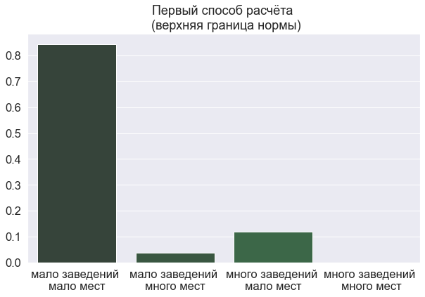

```python
x=['мало заведений \nмало мест', 'мало заведений \nмного мест', 'много заведений \nмало мест', 'много заведений \nмного мест']
y=[(len(chain_table.query('object_count <= 6 and number_median <= 179')) / len(chain_table)),
   (len(chain_table.query('object_count <= 6 and number_median > 179')) / len(chain_table)),
   (len(chain_table.query('object_count > 6 and number_median <= 179')) / len(chain_table)),
   (len(chain_table.query('object_count > 6 and number_median > 179')) / len(chain_table))]

plt.figure(figsize= (10, 6))
ax=sns.barplot(x=x, y=y)
ax.set_title('Первый способ расчёта \n (верхняя граница нормы)')
ax.set_ylabel('');
```

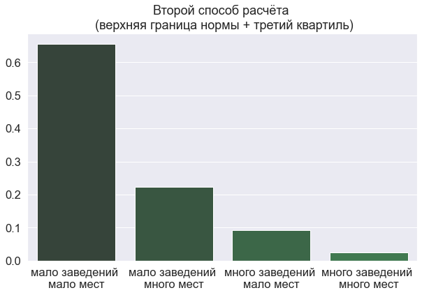

```python
x=['мало заведений \nмало мест', 'мало заведений \nмного мест', 'много заведений \nмало мест', 'много заведений \nмного мест']
y=[(len(chain_table.query('object_count <= 6 and number_median <= 83')) / len(chain_table)),
   (len(chain_table.query('object_count <= 6 and number_median >= 84')) / len(chain_table)),
   (len(chain_table.query('object_count > 6 and number_median <= 83')) / len(chain_table)),
   (len(chain_table.query('object_count > 6 and number_median >= 84')) / len(chain_table))]

plt.figure(figsize= (10, 6))
ax=sns.barplot(x=x, y=y)
ax.set_title('Второй способ расчёта \n (верхняя граница нормы + третий квартиль)')
ax.set_ylabel('');
```

Ещё первый способ расчёта можно визуализировать при помощи самого первого графика в этом шаге. Отметим линиями наши условные границы (больше 6 заведений - это "много заведений", меньше 179 мест - "мало мест")

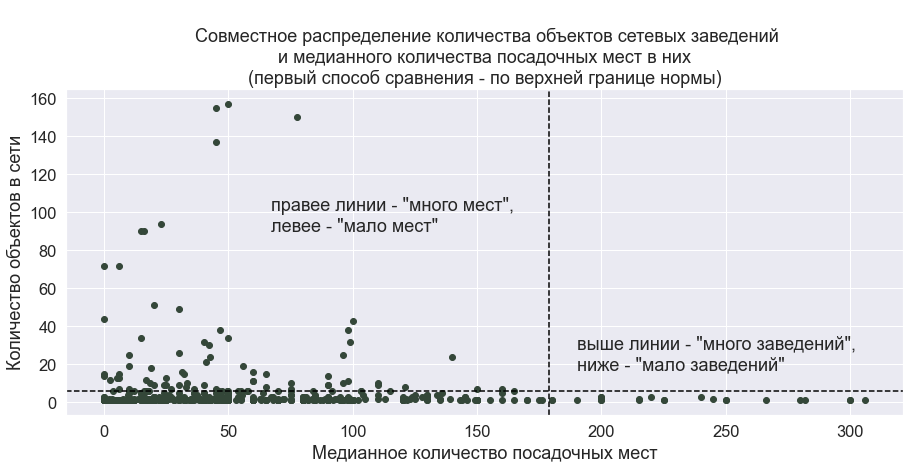

```python
chain_table = chain_yes.groupby('object_name').agg({'object_name' : 'count', 'number' : 'median'})
chain_table.columns = ['object_count', 'number_median']

plt.figure(figsize=(15,6))
plt.scatter(chain_table['number_median'], chain_table['object_count'])
plt.xlabel('Медианное количество посадочных мест')
plt.ylabel('Количество объектов в сети')
plt.title(
    '\n Совместное распределение количества объектов сетевых заведений'
    '\nи медианного количества посадочных мест в них'
    '\n(первый способ сравнения - по верхней границе нормы)')

plt.axhline(y= 6, linestyle='--', color='black')
plt.axvline(x=179, linestyle='--', color='black')
plt.text(190,17, 'выше линии - "много заведений", \nниже - "мало заведений"')
plt.text(67,90, 'правее линии - "много мест", \nлевее - "мало мест"')
plt.show();
```

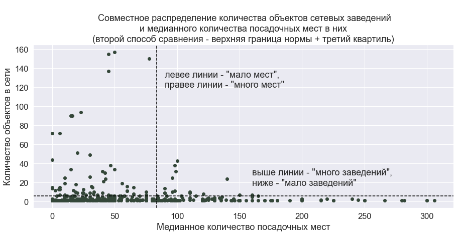

```python
chain_table = chain_yes.groupby('object_name').agg({'object_name' : 'count', 'number' : 'median'})
chain_table.columns = ['object_count', 'number_median']

plt.figure(figsize=(15,6))
plt.scatter(chain_table['number_median'], chain_table['object_count'])
plt.xlabel('Медианное количество посадочных мест')
plt.ylabel('Количество объектов в сети')
plt.title(
    '\n Совместное распределение количества объектов сетевых заведений'
    '\nи медианного количества посадочных мест в них'
    '\n(второй способ сравнения - верхняя граница нормы + третий квартиль)')

plt.axhline(y= 6, linestyle='--', color='black')
plt.axvline(x=83.5, linestyle='--', color='black')
plt.text(160,17, 'выше линии - "много заведений", \nниже - "мало заведений"')
plt.text(90, 120, 'левее линии - "мало мест", \nправее линии - "много мест"')
plt.show();
```

Можно рассмотреть ещё один способ визуализации: на графике разброса попробуем показать, где находится **большинство объектов**.